# sesion_06_04

Unidad Centinela de Infección Respiratoria Aguda Grave (UC-IRAG)

En Argentina, la estrategia de vigilancia de IRAs se estructura en tres componentes, entre los cuales se destaca la vigilancia centinela que permite recolectar datos de manera sistemática y oportuna en un número limitado de establecimientos, seleccionados bajo criterios predefinidos.

A continuación, se presenta la información correspondiente a la vigilancia centinela de IRAG e IRAGe en el Hospital “Dra.(…)” durante el año 2025.

## **Situación epidemiológica**

El **gráfico 1** muestra la distribución por semana de casos notificados durante el año 2025 en la UC-IRAG Hospital “Dra.(..)”.

**Gráfico 1:** Casos notificados de IRAG e IRAGe por semana epidemiológica (N = 404)

[interactive chart not shown]

En el periodo estudiado, se notificaron 304 casos de IRAG y 100 casos de IRAGe.

Los casos de IRAG representaron el 75.2% del total mientras que los casos de IRAGe representaron el 24.8%.

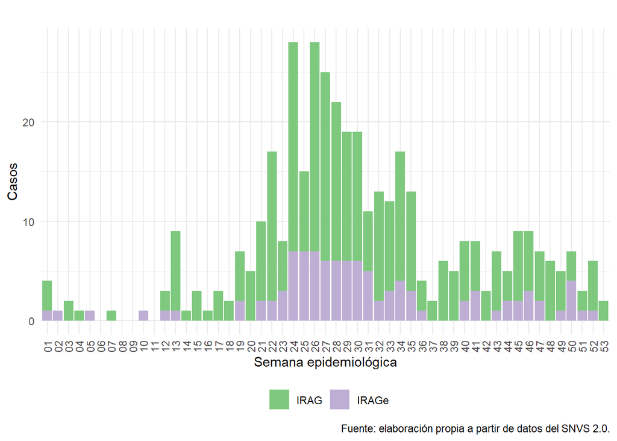

## **Anexos**

- Para más información puede consultar la Guía Operativa de Vigilancia Centinela de IRAG en [la web del Ministerio de Salud.](https://www.argentina.gob.ar/sites/default/files/guia-uc-irag-vff.pdf)